# st_area

Written by Aunoy Poddar May 23rd, 2022

# Process the puncta quantified raw data

```r
current_file <- rstudioapi::getActiveDocumentContext()$path
output_file <- stringr::str_replace(current_file, '.Rmd', '.R')
knitr::purl(current_file, output = output_file)
file.edit(output_file)
```

## Import packages and functions

```r
library(Seurat)
library(tictoc)
library(ggplot2)
library(patchwork)
library(pheatmap)
library(RColorBrewer)
library(tidyverse)
library(gridExtra)
```

## Load the data

```r
data_dir = '/home/aunoy/st/arc_profiling/st_analysis/hand_annotated_data/rethresholded'
output_dir_plot = '/home/aunoy/st/arc_profiling/st_analysis/results/plots'
output_dir_tbls = '/home/aunoy/st/arc_profiling/st_analysis/results/tables'
```

### Merge both datasets and generate a metadata column that corresponds

### to the cell

```r
df = data.frame()
for (file_name in list.files(data_dir)){
  print(file_name)
  #if(grepl('408_TC', file_name) | grepl('408_vMS', file_name)){
  #  next
  #}
  df_to_append <- read.table(file.path(data_dir, file_name), sep = ',', header = TRUE)
  while(length(ind <- which(df_to_append$Image.Name == "")) > 0){
    df_to_append$Image.Name[ind] <- df_to_append$Image.Name[ind -1]
  }
  #df_to_append <- df_to_append %>%
  #  dplyr::select(-1)
  if(grepl('164', file_name)){
    df_to_append <- df_to_append %>%
      dplyr::select(-X)
  }
  colnames(df_to_append) <- toupper(colnames(df_to_append))
  df_to_append <- df_to_append %>%
    mutate(area = strsplit(file_name, '.csv')[[1]])
  if(!is_empty(df)){
    df_to_append <- df_to_append %>%
          dplyr::select(colnames(df))
  }
  df <- rbind(df, df_to_append)
}
```

## Let’s just test by area first

What are our hypothesis? Different streams may reflect different “LGE, MGE, and CGE” markers

|  | p_val | avg_log2FC | pct.1 | pct.2 | p_val_adj |
| --- | --- | --- | --- | --- | --- |
| ASCL1 | 1.556685e-25 | 2.9579458 | 0.854 | 0.449 | 4.981392e-24 |
| MAF1 | 6.661646e-22 | 2.7188435 | 0.556 | 0.115 | 2.131727e-20 |
| PAX6 | 6.098140e-05 | 2.4516301 | 0.485 | 0.348 | 1.951405e-03 |
| RELN | 3.453687e-33 | 2.3356859 | 0.825 | 0.291 | 1.105180e-31 |
| SST | 1.127323e-03 | 1.6385502 | 0.292 | 0.159 | 3.607433e-02 |
| SP8 | 5.348802e-08 | 1.4508040 | 0.895 | 0.943 | 1.711617e-06 |
| SATB2 | 4.633026e-06 | 1.0612579 | 0.877 | 0.771 | 1.482568e-04 |
| DLX2 | 4.758957e-01 | 1.0166009 | 0.316 | 0.322 | 1.000000e+00 |
| VIP | 1.193213e-12 | 0.8224323 | 0.865 | 0.520 | 3.818283e-11 |
| NCAM1 | 1.191014e-06 | 0.6223795 | 0.982 | 0.965 | 3.811244e-05 |

[output cut: 14 more lines]

## Posterior CC vs TC

### CC

ASCL1 - pro… neural? MAF1 - MGE marker later PAX6 - CGE/LGE RELN - signaling molecule SST - Somatostatin SP8 - LGE/CGE

### TC

CALB2 - CGE/LGE neuronal marker (mature) CXCL12 - chemokine NKX2.1 - MGE early marker TSHZ1 - LGE marker

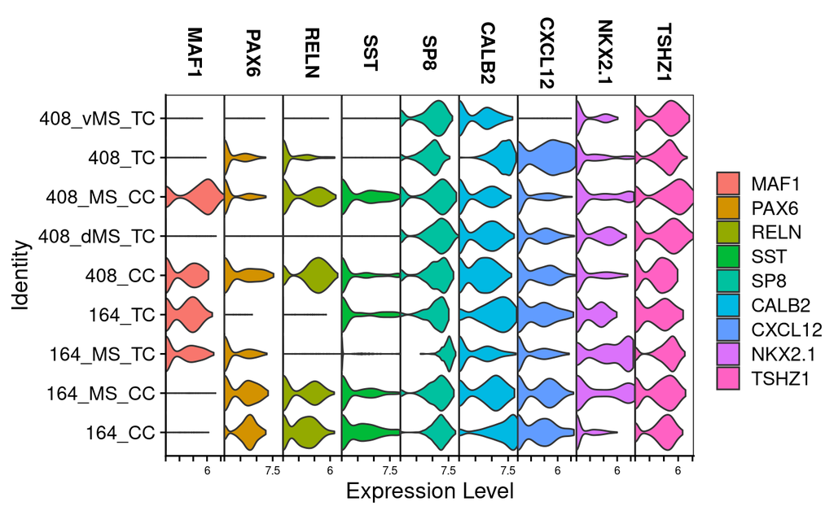

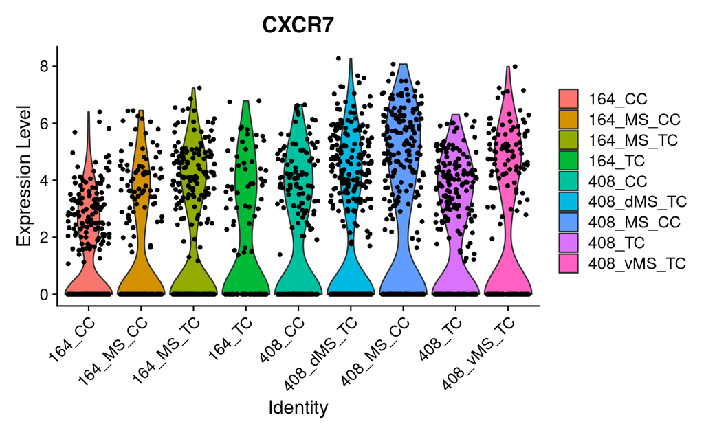

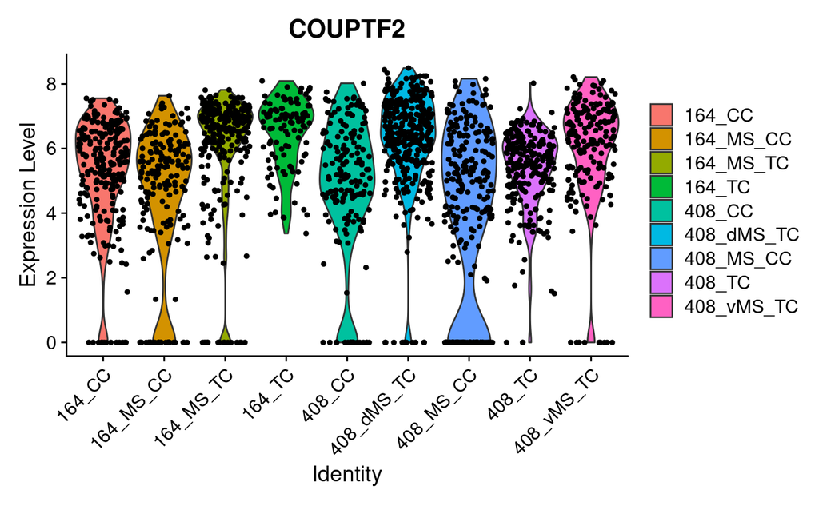

```r
markers <- FindMarkers(jyobj, ident.1 = "408_CC", ident.2 = "164_CC", group.by = 'area')
```

[output not shown]

```r
markers %>%
   slice_max(n = 32, order_by = avg_log2FC)
```

|  | p_val | avg_log2FC | pct.1 | pct.2 | p_val_adj |
| --- | --- | --- | --- | --- | --- |
| GSX2 | 5.310573e-14 | 2.6333302 | 0.585 | 0.285 | 1.699383e-12 |
| NKX2.1 | 1.909550e-01 | 2.5858019 | 0.310 | 0.297 | 1.000000e+00 |
| MAF1 | 1.210877e-13 | 2.0828781 | 0.556 | 0.241 | 3.874807e-12 |
| VIP | 1.630789e-25 | 1.7389168 | 0.865 | 0.378 | 5.218526e-24 |
| CXCR7 | 5.175755e-04 | 1.7315220 | 0.550 | 0.514 | 1.656242e-02 |
| NCAM1 | 4.134484e-26 | 1.7285431 | 0.982 | 0.940 | 1.323035e-24 |
| RELN | 1.701394e-15 | 1.7053339 | 0.825 | 0.695 | 5.444462e-14 |
| SCGN | 1.265839e-17 | 1.1055522 | 1.000 | 0.992 | 4.050686e-16 |
| DCX | 2.390419e-16 | 1.0945801 | 1.000 | 1.000 | 7.649340e-15 |
| LRP8 | 5.231042e-01 | 0.7818967 | 0.737 | 0.892 | 1.000000e+00 |

[output cut: 14 more lines]

## Posterior CC vs anterior CC

### Posterior

GSX2 NKX2.1 MAF1 VIP NCAM1 RELN

### anterior

CALB2 DLX2

```r
markers <- FindMarkers(jyobj, ident.1 = "408_TC", ident.2 = "164_TC", group.by = 'area')
```

[output not shown]

```r
markers %>%
   slice_max(n = 32, order_by = avg_log2FC)
```

|  | p_val | avg_log2FC | pct.1 | pct.2 | p_val_adj |
| --- | --- | --- | --- | --- | --- |
| NKX2.1 | 1.878448e-03 | 2.7299119 | 0.352 | 0.567 | 6.011033e-02 |
| PAX6 | 2.388918e-05 | 2.6109355 | 0.348 | 0.135 | 7.644537e-04 |
| CXCL12 | 6.708472e-06 | 1.7327750 | 0.744 | 0.596 | 2.146711e-04 |
| ASCL1 | 6.801672e-02 | 1.4683048 | 0.449 | 0.385 | 1.000000e+00 |
| NCAM1 | 3.853732e-12 | 1.3561242 | 0.965 | 0.712 | 1.233194e-10 |
| RELN | 9.591521e-02 | 1.1376255 | 0.291 | 0.192 | 1.000000e+00 |
| SCGN | 2.125184e-11 | 1.0972564 | 1.000 | 0.962 | 6.800589e-10 |
| DCX | 5.655871e-10 | 0.7991955 | 1.000 | 1.000 | 1.809879e-08 |
| TSHZ1 | 3.506342e-07 | 0.6117123 | 0.877 | 0.635 | 1.122029e-05 |
| VIP | 6.353304e-01 | 0.5270769 | 0.520 | 0.606 | 1.000000e+00 |

[output cut: 17 more lines]

## Posterior TC vs Anterior TC

### Posterior TC

NKX2.1 PAX6 CXCL12 ASCL1

### Anterior TC

MAF1 CXCR4 SST COUPTF2…. how really?

```r
markers <- FindMarkers(jyobj, ident.1 = "408_CC", ident.2 = "408_MS_CC", group.by = 'area')
```

[output not shown]

```r
markers %>%
   slice_max(n = 32, order_by = avg_log2FC)
```

|  | p_val | avg_log2FC | pct.1 | pct.2 | p_val_adj |
| --- | --- | --- | --- | --- | --- |
| PAX6 | 5.763400e-06 | 1.9112644 | 0.485 | 0.280 | 1.844288e-04 |
| SATB2 | 6.601591e-20 | 1.7299535 | 0.877 | 0.472 | 2.112509e-18 |
| VIP | 5.389746e-13 | 1.4322938 | 0.865 | 0.559 | 1.724719e-11 |
| CXCR4 | 1.545630e-07 | 1.2830510 | 0.731 | 0.512 | 4.946016e-06 |
| CXCL12 | 1.320478e-05 | 1.2675347 | 0.538 | 0.327 | 4.225528e-04 |
| EOMES | 1.861330e-12 | 1.0033335 | 0.637 | 0.264 | 5.956254e-11 |
| RELN | 1.579181e-09 | 0.8899698 | 0.825 | 0.488 | 5.053380e-08 |
| DCX | 3.864995e-10 | 0.8144081 | 1.000 | 1.000 | 1.236798e-08 |
| KIA0319 | 2.623336e-06 | 0.5296952 | 0.678 | 0.378 | 8.394674e-05 |
| ASCL1 | 7.419246e-02 | 0.4173248 | 0.854 | 0.728 | 1.000000e+00 |

[output cut: 16 more lines]

## Posterior CC vs Posterior MS to CC

### Posterior CC

PAX6 SATB2 VIP

### Posterior MS to CC

TSHZ1 NKX2.1 MAF1 VLDLR CXCR7 PROX1 EGFR GSX2

```r
markers <- FindMarkers(jyobj, ident.1 = "164_TC", ident.2 = "164_CC", group.by = 'area')
```

[output not shown]

```r
markers %>%
   slice_max(n = 32, order_by = avg_log2FC)
```

|  | p_val | avg_log2FC | pct.1 | pct.2 | p_val_adj |
| --- | --- | --- | --- | --- | --- |
| GSX2 | 1.202204e-13 | 3.0387663 | 0.635 | 0.285 | 3.847053e-12 |
| MAF1 | 7.191567e-15 | 2.1521785 | 0.654 | 0.241 | 2.301301e-13 |
| LRP8 | 4.101615e-15 | 1.6571094 | 0.990 | 0.892 | 1.312517e-13 |
| CXCR7 | 1.685787e-01 | 1.5635819 | 0.490 | 0.514 | 1.000000e+00 |
| NKX2.1 | 1.298231e-07 | 1.4018882 | 0.567 | 0.297 | 4.154338e-06 |
| TBR1 | 2.478139e-02 | 1.2854976 | 0.712 | 0.707 | 7.930045e-01 |
| CXCR4 | 9.789835e-11 | 1.2640291 | 0.913 | 0.932 | 3.132747e-09 |
| EOMES | 2.611639e-05 | 1.2545795 | 0.808 | 0.739 | 8.357246e-04 |
| COUPTF2 | 9.327951e-13 | 1.1939039 | 1.000 | 0.948 | 2.984944e-11 |
| LHX6 | 1.232323e-05 | 0.8205021 | 0.769 | 0.562 | 3.943433e-04 |

[output cut: 12 more lines]

## anterior TC vs anterior CC

### anterior TC

GSX2 MAF1 LRP8 CXCR7

### anterior CC

PAX6 ASCL1 DLX2 RELN

```r
markers <- FindMarkers(jyobj, ident.1 = "408_TC", ident.2 = "408_dMS_TC", group.by = 'area')
```

[output not shown]

```r
markers %>%
   slice_max(n = 32, order_by = avg_log2FC)
```

|  | p_val | avg_log2FC | pct.1 | pct.2 | p_val_adj |
| --- | --- | --- | --- | --- | --- |
| CXCL12 | 4.761555e-16 | 2.5841676 | 0.744 | 0.489 | 1.523698e-14 |
| CALB2 | 6.059734e-48 | 2.3216910 | 0.996 | 0.664 | 1.939115e-46 |
| SATB2 | 2.019880e-34 | 1.7278999 | 0.771 | 0.236 | 6.463617e-33 |
| NKX2.1 | 1.081717e-05 | 1.2446705 | 0.352 | 0.511 | 3.461496e-04 |
| KIA0319 | 2.703651e-20 | 1.0486259 | 0.903 | 0.480 | 8.651683e-19 |
| VIP | 1.337844e-02 | 0.9682493 | 0.520 | 0.411 | 4.281102e-01 |
| SCGN | 4.871859e-11 | 0.6605932 | 1.000 | 0.902 | 1.558995e-09 |
| RELN | 1.888934e-04 | 0.4377668 | 0.291 | 0.152 | 6.044588e-03 |
| GAD1 | 1.787256e-01 | 0.3115773 | 0.885 | 0.750 | 1.000000e+00 |
| DCDC2 | 2.111384e-01 | -0.2630233 | 0.767 | 0.612 | 1.000000e+00 |

[output cut: 18 more lines]

## Posterior TC vs Posterior dorsal migratory stream

### Posterior TC

CXCL12 CALB2 SATB2

### dorsal migratory stream

MAF1 ASCL1 EMX1 DLX2 PROX1 SP8 LHX6 COUPTF2

```r
markers <- FindMarkers(jyobj, ident.1 = "408_TC", ident.2 = "408_vMS_TC", group.by = 'area')
```

[output not shown]

```r
markers %>%
   slice_max(n = 32, order_by = avg_log2FC)
```

|  | p_val | avg_log2FC | pct.1 | pct.2 | p_val_adj |
| --- | --- | --- | --- | --- | --- |
| SATB2 | 7.612653e-42 | 3.6269506 | 0.771 | 0.089 | 2.436049e-40 |
| CXCL12 | 5.084273e-34 | 3.6249543 | 0.744 | 0.132 | 1.626967e-32 |
| NKX2.1 | 2.917475e-01 | 3.0331148 | 0.352 | 0.289 | 1.000000e+00 |
| CALB2 | 1.588175e-46 | 2.8934990 | 0.996 | 0.526 | 5.082160e-45 |
| VIP | 5.231182e-15 | 2.2467502 | 0.520 | 0.158 | 1.673978e-13 |
| RELN | 2.814980e-11 | 2.0482886 | 0.291 | 0.037 | 9.007935e-10 |
| KIA0319 | 1.068607e-25 | 1.9113593 | 0.903 | 0.395 | 3.419541e-24 |
| PAX6 | 7.208327e-13 | 1.8522210 | 0.348 | 0.053 | 2.306665e-11 |
| ASCL1 | 8.695514e-08 | 1.6624244 | 0.449 | 0.189 | 2.782565e-06 |
| GAD1 | 6.392379e-19 | 1.6352851 | 0.885 | 0.468 | 2.045561e-17 |

[output cut: 20 more lines]

## Posterior TC vs Posterior ventral migratory stream

### Posterior TC

SATB2 CXCL12 NXK2.1 CALB2 VIP RELN KIA0319 PAX6 ASCL1 GAD1

### ventral migratory stream

TBR1 LRP8

```r
markers <- FindMarkers(jyobj, ident.1 = "408_vMS_TC", ident.2 = "408_dMS_TC", group.by = 'area')
```

[output not shown]

```r
markers %>%
   slice_max(n = 32, order_by = avg_log2FC)
```

|  | p_val | avg_log2FC | pct.1 | pct.2 | p_val_adj |
| --- | --- | --- | --- | --- | --- |
| TBR1 | 2.179501e-33 | 2.1288039 | 0.842 | 0.474 | 6.974402e-32 |
| CXCL14 | 3.057097e-03 | 0.8531296 | 0.663 | 0.572 | 9.782711e-02 |
| DCX | 6.403664e-19 | 0.6554002 | 1.000 | 0.991 | 2.049173e-17 |
| SST | 1.068414e-01 | 0.6230410 | 0.074 | 0.124 | 1.000000e+00 |
| EGFR | 3.491569e-02 | 0.5018939 | 0.642 | 0.598 | 1.000000e+00 |
| SCGN | 2.253541e-05 | 0.4217008 | 0.979 | 0.902 | 7.211332e-04 |
| COUPTF2 | 4.429737e-02 | -0.3069214 | 0.953 | 0.968 | 1.000000e+00 |
| EOMES | 7.014641e-02 | -0.4738676 | 0.611 | 0.670 | 1.000000e+00 |
| GSX2 | 7.118580e-01 | -0.4814989 | 0.589 | 0.526 | 1.000000e+00 |
| NCAM1 | 2.756623e-03 | -0.5359262 | 0.837 | 0.868 | 8.821194e-02 |

[output cut: 18 more lines]

### vMS

TBR1 - Excitatory immature? Deep brain marker 1, highly expressed in deep layers

### dMS

ASCL1 - MASH1, proneural MAF1 - MGE CXCR4 - Chemokine receptor SATB2 - Excitatory mature? NXK2.1 - MGE RELN - Signaling molecule

Question… what is happening to the other markers? Are they moving up or down? So we can ignore MAF1 NXK2.1 is going down… that makes sense CXCR4: receptor is going down, and ligand signaling is going down? Is the ligand pulling along other cells? That would be pretty interesting TBR1: strangely going up. Maybe if we take GAD1 cells specifically this might be different

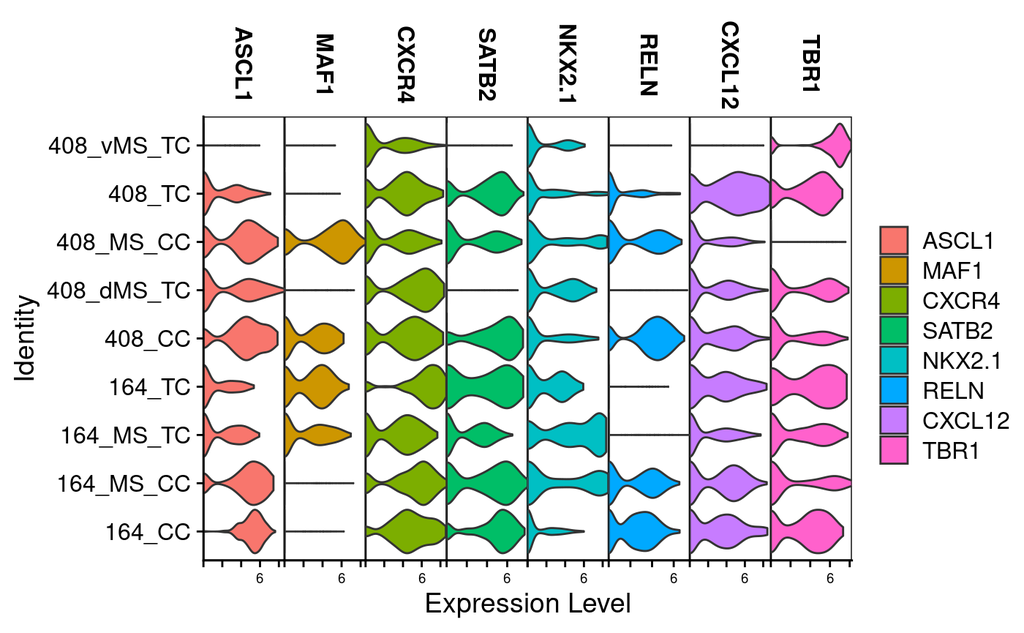

```r
markers <- FindMarkers(jyobj, ident.1 = "164_TC", ident.2 = "164_MS_TC", group.by = 'area')
```

[output not shown]

```r
markers %>%
   slice_max(n = 32, order_by = avg_log2FC)
```

|  | p_val | avg_log2FC | pct.1 | pct.2 | p_val_adj |
| --- | --- | --- | --- | --- | --- |
| CXCR4 | 5.785225e-26 | 3.1759189 | 0.913 | 0.664 | 1.851272e-24 |
| SATB2 | 8.683682e-07 | 2.8864995 | 0.654 | 0.519 | 2.778778e-05 |
| KIA0319 | 4.606910e-12 | 2.7591060 | 0.692 | 0.366 | 1.474211e-10 |
| CALB2 | 3.275655e-20 | 2.4536119 | 0.885 | 0.474 | 1.048210e-18 |
| GAD1 | 8.648986e-12 | 1.9313962 | 0.875 | 0.586 | 2.767676e-10 |
| DCDC2 | 9.939876e-05 | 1.7627346 | 0.567 | 0.414 | 3.180760e-03 |
| VIP | 2.784971e-01 | 1.6949334 | 0.606 | 0.616 | 1.000000e+00 |
| SST | 7.781311e-02 | 1.6478107 | 0.308 | 0.250 | 1.000000e+00 |
| CXCL12 | 1.357656e-03 | 1.5593458 | 0.596 | 0.407 | 4.344499e-02 |
| CXCL14 | 3.832048e-08 | 1.3960392 | 0.663 | 0.340 | 1.226255e-06 |

[output cut: 19 more lines]

## anterior TC vs anterior TC stream

### anterior TC

CXCR4 - Receptor 4 SATB2 - Excitatory KIA0319 - Disease Dyslexia CALB2 - Excitatory mature DCDC2 - Disease Dyslexia VIP - Mature SST - Mature CXCL12 - Signaling ligand

### Anterior TC stream

NXK2.1 - MGE PAX6 - CGE/LGE Marker SP8 - CGE/LGE DLX2 - Broad GABAergic